# CS 372/472 & LRN_SCI 372/472

Thought Experiments and ABM

Prof. Connor Bain

connor.bain@northwestern.edu

April 14, 2026

## Logistical Stuff

**Exercise 3**

Is due on SUNDAY at 11:59pm via Canvas. **It requires a partner!** We’ll have some time at the end of class to help arrange partners.

- The CCL (the lab here at NU that works on all things NetLogo) is hiring interns this summer! [Apply here](https://sun-scilla-d54.notion.site/3118b351536580eead76ff0501aa35f9). Feel free to come and chat with me if you’re interested in hearing more.
- Please make sure to follow along in the textbook. There are lots more examples in there that might be more interesting to you than the ones we get to in class.

## A Brief Re-visit of 1D CAs

- Wolfram, in 1994 enumerated and classified “all” 1D Cellualr automata
- Then he wrote a whole book about them called *A New Kind of Science* (Wolfram 2002)
  - It suggested that *all of science* can be derived from CAs
  - He wasn’t the only one: Zuse & Fredkin also worked on these ideas
  - The “key insight” was that, like the world, CAs are *discrete*

## 1D Cellular Automata

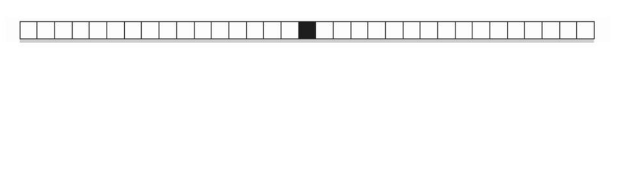

Start Value

## The Neighborhood Rules

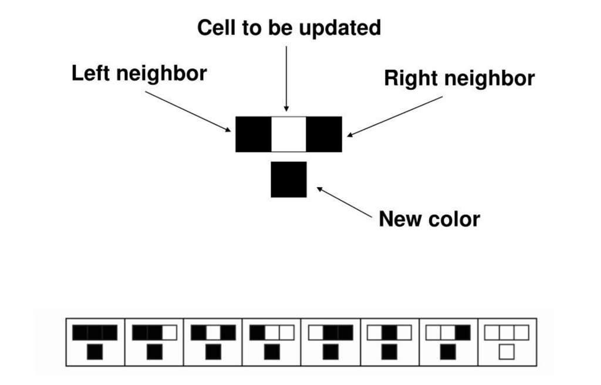

Tick Rules

## The Y-Dimension is Time

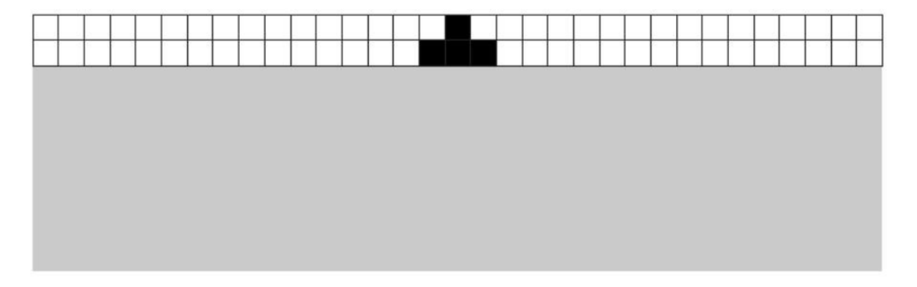

2nd Generation

## The Y-Dimension is Time

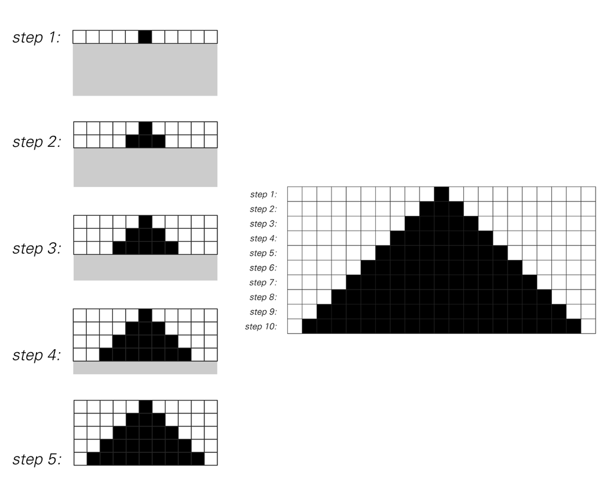

many generations

## Some Rules are…not interesting

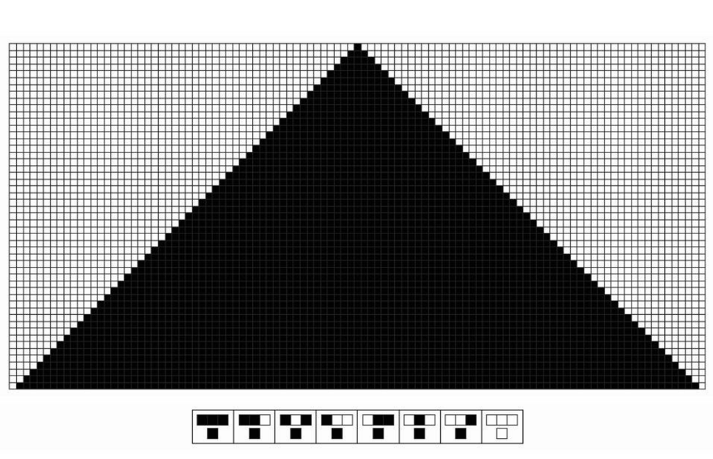

many generations

## CA 1D - Rule 30

- Why might we call this `Rule 30`?

| Current Neighborhood | 111 | 110 | 101 | 100 | 011 | 010 | 001 | 000 |
| --- | --- | --- | --- | --- | --- | --- | --- | --- |
| Next State for Center | 0 | 0 | 0 | 1 | 1 | 1 | 1 | 0 |

- In this way, we can uniquely refer to any of the 1D CAs of this family.
- Which then means we can try to start classifying their behaviors.

## 256 Rules in Total

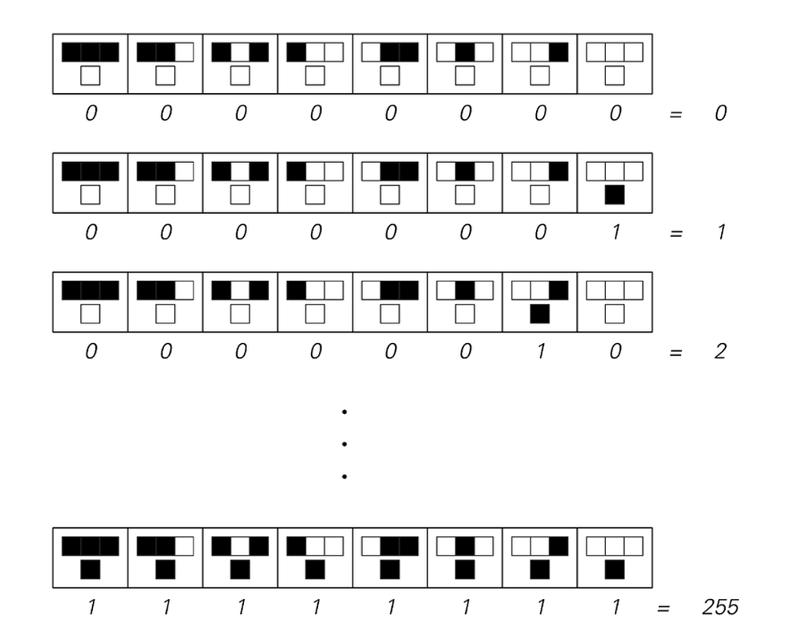

Some Examples

## What rule is this?

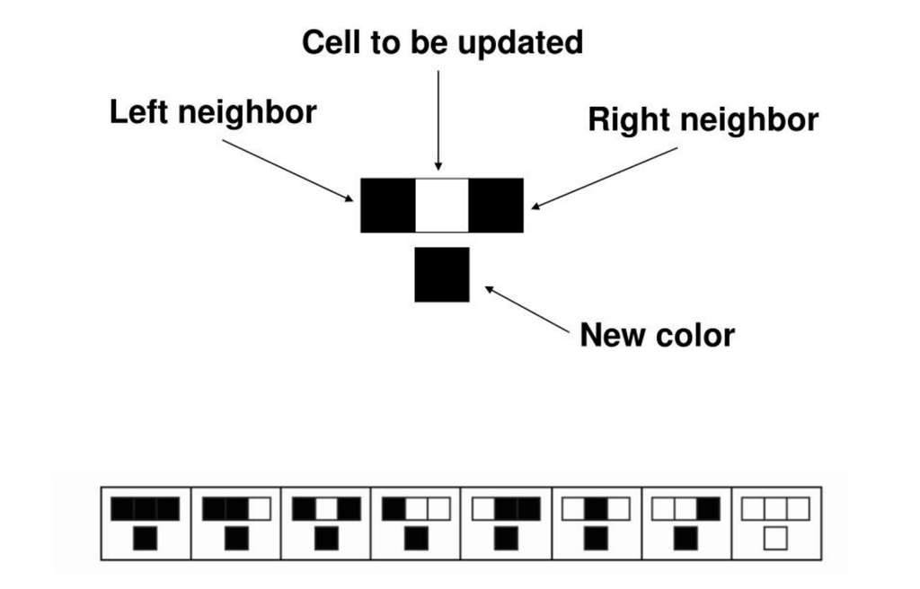

Tick Rules

## Cool Behavior 1

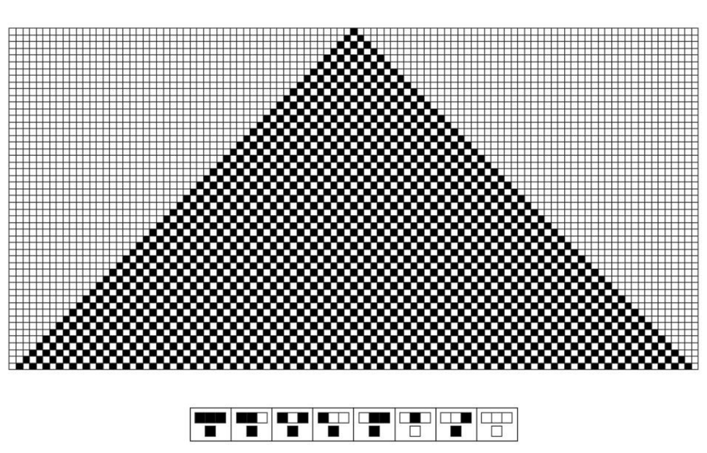

Tick Rules

## Cool Behavior 2

[figure not shown]

Tick Rules

## Cool Behavior 3

[figure not shown]

Tick Rules

## Rule 30

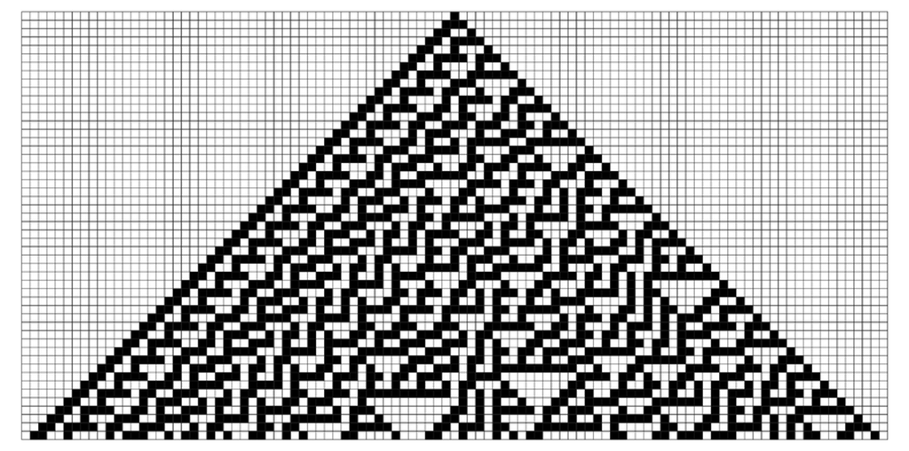

Tick Rules

## Rule 30 Zoom Out

[figure not shown]

Tick Rules

## Rule 30 Zoom Out MORE

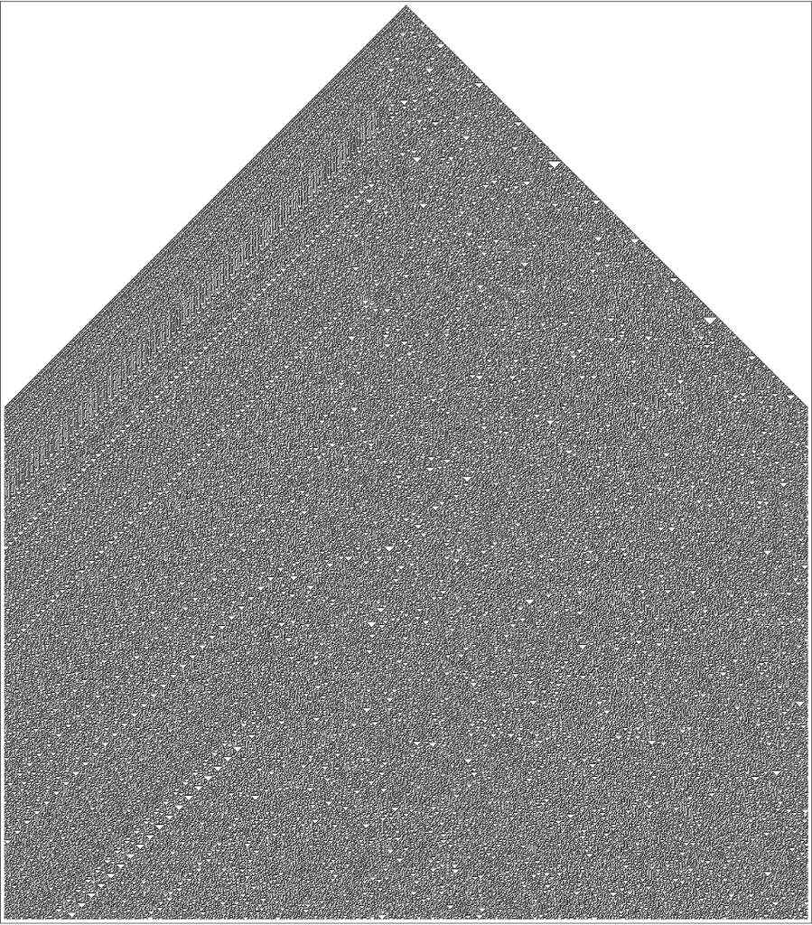

Tick Rules

## Rule 30 Zoom IN

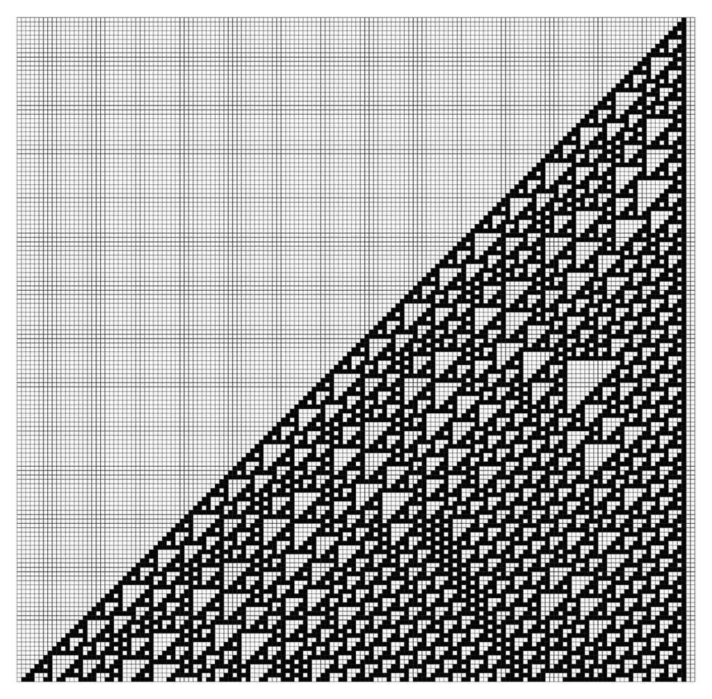

Tick Rules

## Rule 30 Zoom IN

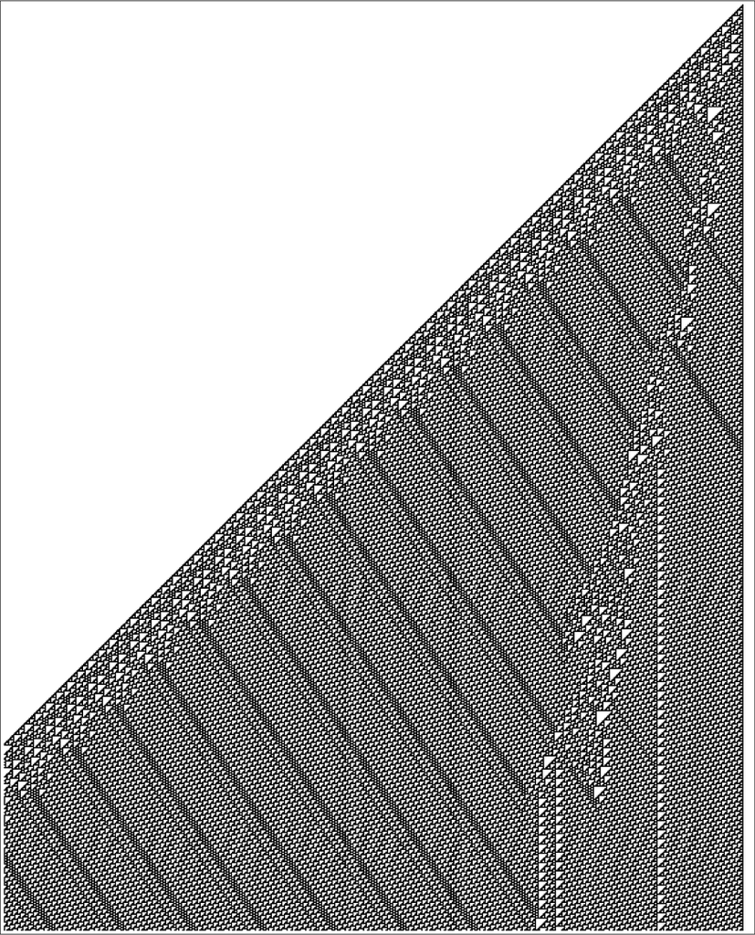

Tick Rules

## Rule 30 Zoom IN

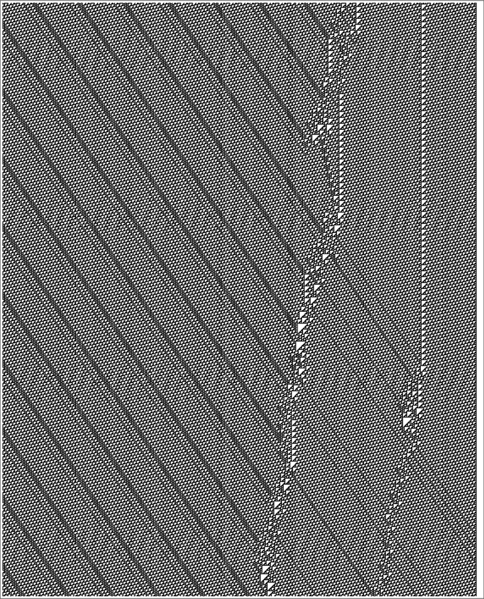

Tick Rules

## Rule 30 Zoom IN

[figure not shown]

Tick Rules

## Other Cool Examples

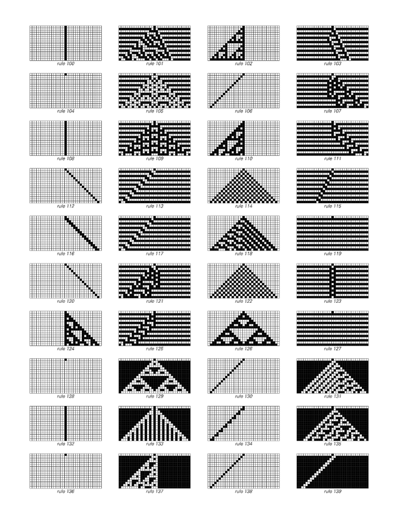

Various examples

## Wolfram’s Classifications

- **Class 1** - *homogenous*: Dominated by a unique state
- **Class 2** - *periodic*: Blocks of cells repeat every `n` generations
- **Class 3** - *chaotic*: No apparent order over long period
- **Class 4** - *complex*: Evolving structures that include combinations of the other three

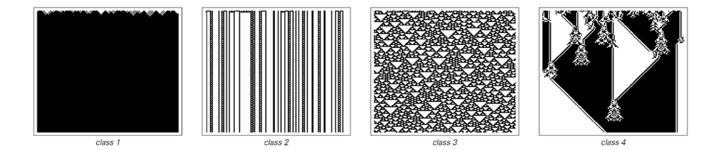

Examples of Class 1 through 4

## But why bother?

- Konrad Zuse wrote a book on automata theory where he proposed all processes in the universe are computational. (Zuse 1970)
- This theory has stuck around: Ed Fredkin (1990) – “We hypothesize that there will be found a single CA rule that models all of microscopic physics”
- In the early 2000s, Matthew Cook proved some rules (including Rule 110) are Turing complete universal computers. (Cook et al. 2004)

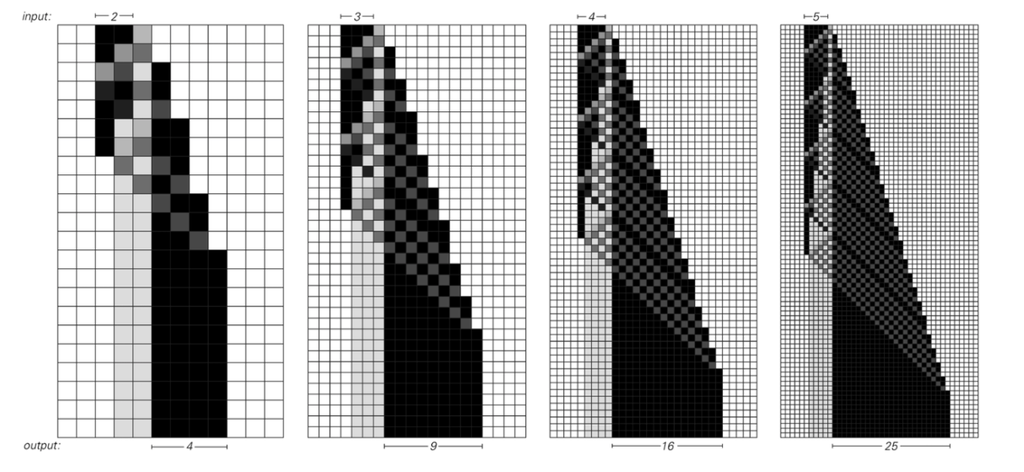

Squaring a number

## Again, why?

- If you’re interested, great! There are lots of other Cellular Automata Models: Discrete; Continuous; even Neural.
- We study these systems for their *emergent properties*.
- However, we’re still not at a point where we could simulate a CA in the scale of say, the number of cells in your body.
- ABM (agent-based modeling) is built on the same principles – small rules give rise to complex behavior

# Student Presentation - Stella

## Thought Experiments

### The goal of a thought experiment is to explore the potential consequences of a principle or a hypothetical situation

The German’s have a special word for this idea: gedankenexperiment. You’ve heard of these before:

- [Schrodinger’s Cat](https://www.youtube.com/watch?v=IOYyCHGWJq4)
- Maxwell’s Demon
- The Trolley Problem
- The Twin Paradox

# Student Presentation - Ruoyi

# ABM and Economics

**Behavioral economics** studies the effects of psychological, cognitive, emotional, cultural, and social factors on the economic decisions of individual institutions.

- It interests itself in how those decisions might differ from what classical theory implies.
- Classical theory assumes “maximally rational agents”
- Of course, humans are weird. We’re more likely to exhibit [bounded rationality](https://en.wikipedia.org/wiki/Bounded_rationality)
- In most studies, it’s found that humans don’t act like perfect rational agents, and instead use *heuristics* (rules of thumb) to make decisions (in other words, ignore a bunch of stuff)

## A Simple Economy Thought Experiment

### SETUP

- Imagine 500 people are in a room.
- Each person gets $100.

### GO

- At each tick of the clock, each person picks a random other person to receive one of their dollars ($1).
  - If a person has $0, they don’t give anything away.

**What shape will the distribution of wealth be after a while?**

- This is sometimes referred to as the Boltzmann-Gibbs wealth model.
- Yes, that’s the same Boltzman as the [Boltzmann distribution](https://en.wikipedia.org/wiki/Boltzmann_distribution) from statistical mechanics.
- Any set of interacting agents that exchange a conserved quantity that cannot become negative will always result in such an exponential distribution.
- *Power law distributions* arise in a surprising number of contexts and are typically associated with a *preferential attachment* processes

## How could we extend?

- Empirical studies have shown that wealth distribution in most countries is not distributed exponentially but rather as a power law known as the [Pareto distribution](https://en.wikipedia.org/wiki/Pareto_distribution).

### What small tweaks could we make to the model to make it more representative of the real world?

- Dragulescu and Yakovenko (2000) wrote a whole paper on minor changes and their effects

# Econophysics

- Gene Stanley coined the term econophysics for this interdisciplinary research field. (Mantegna and Stanley 1999)

## References

Cook, Matthew et al. 2004. “Universality in Elementary Cellular Automata.” *Complex Systems* 15 (1): 1–40.

Dragulescu, Adrian, and Victor M Yakovenko. 2000. “Statistical Mechanics of Money.” *The European Physical Journal B-Condensed Matter and Complex Systems* 17 (4): 723–29.

Mantegna, Rosario N, and H Eugene Stanley. 1999. *Introduction to Econophysics: Correlations and Complexity in Finance*. Cambridge university press.

Wolfram, Stephen. 2002. *A New Kind of Science*. Wolfram Media.

Zuse, Konrad. 1970. *Calculating Space*. MIT Technical Translation, AZT-70-164-GEMIT.